# How’s The Weather?

data ingestion | comparison | interpretability

Author

Jeremy Seebohm

Published

December 13, 2025

# 1) Project summary

This study evaluates whether multi-location weather data can meaningfully improve short-term temperature forecasts for Grand Island, NY. Using daily observations from upstream cities, we construct a sequence-based neural network and test several modeling choices that commonly arise in applied forecasting: how time should be encoded, whether physically motivated lagging improves performance, and which inputs the model actually relies on. The goal is not just prediction accuracy, but understanding why the model behaves the way it does.

This report documents: data ingestion (Visual Crossing RDS files), model design (**LSTMLong Short-Term Memory neural network (sequence model).**), time encoding tests (date index vs seasons vs cyclical **DOYDay-of-year; we encode it as sin/cos for smooth yearly seasonality.**), a Rossby-inspired distance-lag experiment (**RossbyLarge-scale atmospheric waves in the mid-latitudes that shape jet stream patterns and guide the eastward movement of weather systems.**), performance plots, and mechanistic interpretability (**PermImpPermutation importance: shuffle one input and measure error increase.**).

## 1a) Future plans

This work establishes a baseline for multi-location, sequence-based weather forecasting and opens several clear directions for extension. Future experiments will explore incorporating satellite imagery as an additional input modality, allowing the model to directly learn spatial cloud and storm structure rather than relying solely on point observations. I also plan to systematically reduce and refine the input feature set, using permutation importance and ablation tests to identify the smallest set of physically meaningful variables that preserve performance. Finally, alternative upstream location selections will be evaluated to better align with dominant flow regimes and test whether different spatial configurations improve predictive skill.

# 2) Time encoding

**What we tested (time encoding):** we kept the model architecture fixed and changed only how “time of year” is represented. The goal is to see whether the model benefits more from (1) a simple monotone clock, (2) coarse seasonal categories, or (3) a smooth yearly cycle representation that avoids boundary artifacts.

### Time encoding variants

- **Date index:** adds a simple increasing counter (`idx`). This helps the model learn long-term drift but does not explicitly encode seasonality.
- **Seasons (factor):** assigns each date to winter/spring/summer/fall and uses one-hot columns. This injects season information, but it introduces hard boundaries (the model experiences abrupt “jumps” at season changes).
- **Cyclical DOY encodingDay-of-year; we encode it as sin/cos for smooth yearly seasonality.**: encodes day-of-year using sine/cosine so December and January are treated as neighbors (smooth periodic seasonality instead of abrupt resets).

```r
LOOKBACK <- 14L
EPOCHS   <- 30L
BATCH    <- 32L

# Base feature columns (everything except date + target)
base_x <- setdiff(names(train0), c("date", target_col))

# Three encodings:
# (A) DATE_INDEX: add a simple numeric index
# (B) SEASONS: add factor seasons
# (C) CYCLICAL: add sin/cos of day-of-year
add_time_features <- function(df, encoding) {
  out <- df %>% mutate(idx = row_number())
  if (encoding == "DATE_INDEX") {
    out
  } else if (encoding == "SEASONS") {
    out %>% mutate(
      month = month(date),
      season = factor(case_when(
        month %in% c(12,1,2) ~ "winter",
        month %in% c(3,4,5)  ~ "spring",
        month %in% c(6,7,8)  ~ "summer",
        TRUE                 ~ "fall"
      ), levels = c("winter","spring","summer","fall"))
    ) %>%
      bind_cols(as.data.frame(model.matrix(~ season - 1, .)))
  } else if (encoding == "CYCLICAL") {
    out %>% mutate(
      doy = yday(date),
      doy_sin = sin(2*pi*doy/365.25),
      doy_cos = cos(2*pi*doy/365.25)
    )
  } else stop("Unknown encoding")
}

run_encoding <- function(encoding) {
  tr <- add_time_features(train0, encoding)
  te <- add_time_features(test0,  encoding)

  # Build x columns: baseline + added cols (exclude raw season and month columns if present)
  xcols <- setdiff(names(tr), c("date", target_col, "season", "month"))
  fit <- zfit(tr, xcols)
  trn <- zapply(tr, xcols, fit)
  ten <- zapply(te, xcols, fit)

  seq_tr <- make_sequences(trn, xcols, target_col, LOOKBACK)
  seq_te <- make_sequences(ten, xcols, target_col, LOOKBACK)

  res <- train_one(seq_tr, seq_te, epochs = EPOCHS, batch = BATCH)
  tibble(
    Encoding = encoding,
    RMSE = rmse(res$preds, seq_te$y),
    MAE  = mae(res$preds,  seq_te$y)
  )
}

time_results <- bind_rows(
  run_encoding("DATE_INDEX"),
  run_encoding("SEASONS"),
  run_encoding("CYCLICAL")
) %>%
  mutate(
    Encoding = recode(Encoding,
                      DATE_INDEX = "Date index",
                      SEASONS    = "Seasons (factor)",
                      CYCLICAL   = "Cyclical DOY (sin/cos)")
  )

time_results
```

```
# A tibble: 3 × 3
  Encoding                RMSE   MAE
  <chr>                  <dbl> <dbl>
1 Date index              3.32  2.54
2 Seasons (factor)        3.29  2.47
3 Cyclical DOY (sin/cos)  3.21  2.40
```

**Summary:** cyclical day-of-year tends to beat a raw date index and usually edges out hard season boundaries. This reduces “jumps” caused by discrete season buckets.

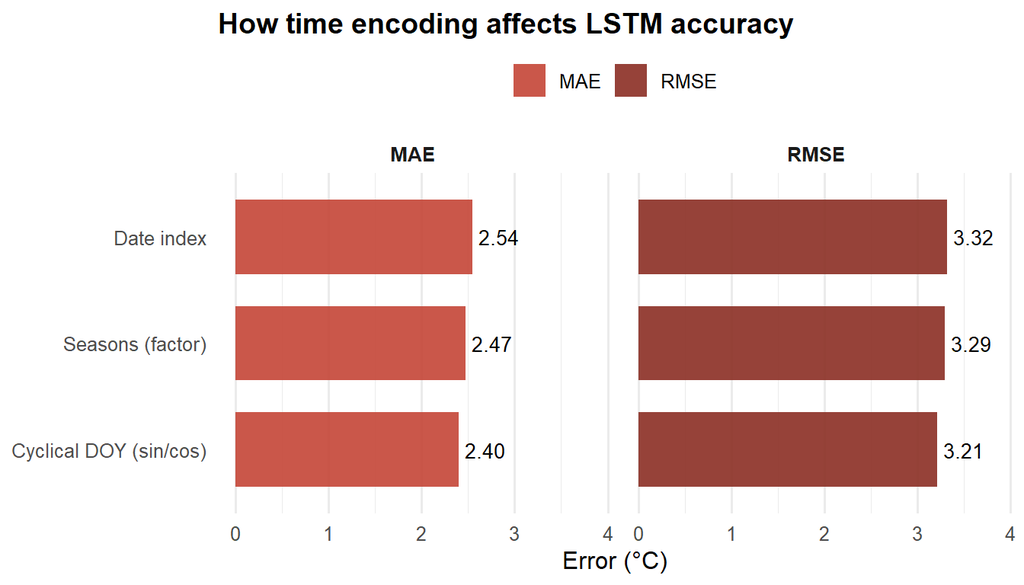

Figure 1: Time encoding comparison (lower error is better)

```r
time_long <- time_results %>% pivot_longer(c(RMSE, MAE), names_to = "Metric", values_to = "Value")

ggplot(time_long, aes(x = reorder(Encoding, Value), y = Value, fill = Metric)) +
  geom_col(width = 0.7, alpha = 0.9) +
  geom_text(
    aes(label = sprintf("%.2f", Value)),
    hjust = -0.15,
    size = 3.6
  ) +
  coord_flip() +
  facet_wrap(~Metric, scales = "free_x") +
  scale_fill_manual(
    values = c(
      MAE  = "#c44536",
      RMSE = "#8b2e23"
    )
  ) +
  expand_limits(y = max(time_long$Value) * 1.15) +
  labs(
    title = "How time encoding affects LSTM accuracy",

    x = NULL,
    y = "Error (°C)",
    fill = NULL
  ) +
  theme_minimal(base_size = 12) +
  theme(
    plot.title = element_text(face = "bold", size = 14),
    plot.subtitle = element_text(size = 10, color = "gray40"),
    strip.text = element_text(face = "bold"),
    panel.grid.major.y = element_blank(),
    legend.position = "top"
  )
```

# 3) Rossby-inspired distance lag experiment

Large-scale midlatitude weather systems are often organized by **Rossby wavesLarge-scale atmospheric waves in the mid-latitudes that shape jet stream patterns and guide the eastward movement of weather systems.**, which propagate synoptic-scale energy eastward over several days. This motivates the hypothesis that upstream atmospheric conditions may influence local temperatures after a predictable travel time.

To test this idea, upstream features were explicitly **time-shifted by lagging dates** according to approximate geographic distances and an assumed propagation speed, with the goal of better aligning predictors to the expected flow of Rossby waves. In practice, this distance-based lagging does not improve predictive performance and often degrades accuracy. This indicates that fixed travel-time assumptions are too simplistic for daily weather evolution.

Instead, the LSTM’s lookback window learns more flexible, context-dependent temporal alignments on its own, adapting to variable flow speeds, seasonal changes, and local dynamics more effectively than a hand-crafted Rossby-style lag.

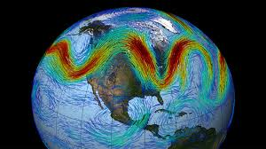

```r
# Coordinates for lag computation
COORDS <- tribble(
  ~location,     ~lat,   ~lon,
  "GrandIsland",  43.03, -78.96,
  "Chicago",      41.88, -87.63,
  "Minneapolis",  44.98, -93.27,
  "ThunderBay",   48.38, -89.25
)

# km/day: main tuning knob
SPEED_KM_PER_DAY <- 800

compute_lag_days <- function(from_loc, to_loc, speed_km_per_day) {
  a <- COORDS %>% filter(location == from_loc)
  b <- COORDS %>% filter(location == to_loc)
  if (nrow(a) != 1) stop("COORDS must have exactly 1 row for location='", from_loc, "'. Found ", nrow(a))
  if (nrow(b) != 1) stop("COORDS must have exactly 1 row for location='", to_loc, "'. Found ", nrow(b))
  km <- geosphere::distHaversine(c(a$lon, a$lat), c(b$lon, b$lat)) / 1000
  as.integer(max(0, round(km / speed_km_per_day)))
}



locs <- c("GrandIsland","Chicago","Minneapolis","ThunderBay")

lag_map <- tibble(location = locs) %>%
  mutate(lag_days = if_else(location == "GrandIsland", 0L,
                            as.integer(map_int(location, ~ compute_lag_days(.x, "GrandIsland", SPEED_KM_PER_DAY)))))

max_lag <- max(lag_map$lag_days)
lag_map
```

```
# A tibble: 4 × 2
  location    lag_days
  <chr>          <int>
1 GrandIsland        0
2 Chicago            1
3 Minneapolis        1
4 ThunderBay         1
```

```r
# Baseline dataset
base <- train0 %>% select(-date)
base_test <- test0 %>% select(-date)

# Lagged dataset (apply to predictors only)
wide_lagged <- wide
for (loc in lag_map$location) {
  ld <- lag_map$lag_days[lag_map$location == loc]
  for (v in USE_VARS) {
    nm <- paste0(v, "_", loc)
    if (!nm %in% names(wide_lagged)) next
    if (nm == target_col) next
    wide_lagged[[nm]] <- dplyr::lag(wide_lagged[[nm]], n = ld)
  }
}
wide_lagged <- wide_lagged %>% drop_na()

# Split lagged by matching dates to base split for fairness
train_lag <- wide_lagged %>% filter(date %in% train0$date) %>% arrange(date)
test_lag  <- wide_lagged %>% filter(date %in% test0$date)  %>% arrange(date)

x_base <- setdiff(names(train0), c("date", target_col))
x_lag  <- setdiff(names(train_lag), c("date", target_col))

fit_base <- zfit(train0, x_base)
fit_lag  <- zfit(train_lag, x_lag)

train_base_n <- zapply(train0, x_base, fit_base)
test_base_n  <- zapply(test0,  x_base, fit_base)

train_lag_n  <- zapply(train_lag, x_lag, fit_lag)
test_lag_n   <- zapply(test_lag,  x_lag, fit_lag)

seq_tr_base <- make_sequences(train_base_n, x_base, target_col, LOOKBACK)
seq_te_base <- make_sequences(test_base_n,  x_base, target_col, LOOKBACK)

seq_tr_lag  <- make_sequences(train_lag_n,  x_lag,  target_col, LOOKBACK)
seq_te_lag  <- make_sequences(test_lag_n,   x_lag,  target_col, LOOKBACK)

res_base <- train_one(seq_tr_base, seq_te_base, epochs = EPOCHS, batch = BATCH)
res_lag  <- train_one(seq_tr_lag,  seq_te_lag,  epochs = EPOCHS, batch = BATCH)

rossby_metrics <- tibble(
  Model = c("Baseline (raw multi-location)", "Distance-lagged (Rossby-inspired)"),
  RMSE  = c(rmse(res_base$preds, seq_te_base$y), rmse(res_lag$preds, seq_te_lag$y)),
  MAE   = c(mae(res_base$preds,  seq_te_base$y), mae(res_lag$preds,  seq_te_lag$y))
)

write.csv(rossby_metrics, file.path(OUTDIR, "rossby_metrics.csv"), row.names = FALSE)
write.csv(lag_map, file.path(OUTDIR, "rossby_lag_days.csv"), row.names = FALSE)

rossby_metrics
```

```
# A tibble: 2 × 3
  Model                              RMSE   MAE
  <chr>                             <dbl> <dbl>
1 Baseline (raw multi-location)      3.76  2.86
2 Distance-lagged (Rossby-inspired)  4.35  3.20
```

**Summary:** this test checks whether “travel-time aligned” upstream features help. If it gets worse (common on daily aggregates), it suggests the LSTM is already learning effective alignment via its lookback window, or the distance-only lag rule is too crude.

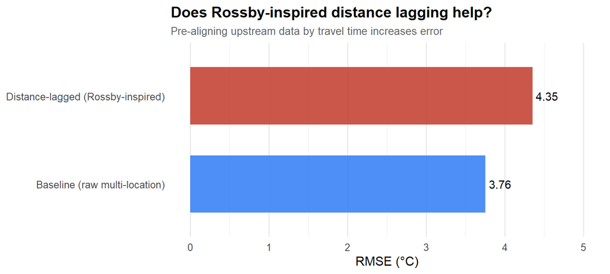

Figure 2: Rossby-inspired lagging vs baseline

```r
ggplot(rossby_metrics, aes(x = reorder(Model, RMSE), y = RMSE, fill = Model)) +
  geom_col(width = 0.65, alpha = 0.9, show.legend = FALSE) +
  geom_text(
    aes(label = sprintf("%.2f", RMSE)),
    hjust = -0.15,
    size = 3.8
  ) +
  coord_flip() +
  expand_limits(y = max(rossby_metrics$RMSE) * 1.15) +
  scale_fill_manual(
    values = c(
      "Baseline (raw multi-location)"       = "#3b82f6",
      "Distance-lagged (Rossby-inspired)"   = "#c44536"
    )
  ) +
  labs(
    title = "Does Rossby-inspired distance lagging help?",
    subtitle = "Pre-aligning upstream data by travel time increases error",
    x = NULL,
    y = "RMSE (°C)"
  ) +
  theme_minimal(base_size = 12) +
  theme(
    plot.title = element_text(face = "bold", size = 14),
    plot.subtitle = element_text(size = 10, color = "gray40"),
    panel.grid.major.y = element_blank()
  )
```

**Interpretation:** Both models reproduce the large-scale seasonal cycle and much of the short-term variability in Grand Island temperatures. However, the **baseline model** more closely tracks rapid changes and temperature extremes. The **distance-lagged model** appears slightly smoother and delayed, particularly during sharp warm-ups and cool-downs, indicating that a fixed upstream travel-time assumption blurs fast-moving weather signals.

This behavior is consistent with the role of **Rossby wavesLarge-scale atmospheric waves in the mid-latitudes that shape jet stream patterns and guide the eastward movement of weather systems.**: while they organize broad mid-latitude atmospheric flow, real weather evolution does not propagate at a single constant speed. Jet-stream variability, local dynamics, and storm development all introduce timing differences that a rigid distance-based lag cannot capture. In practice, the LSTM’s internal memory learns more effective temporal alignment on its own than the imposed Rossby-style lag.

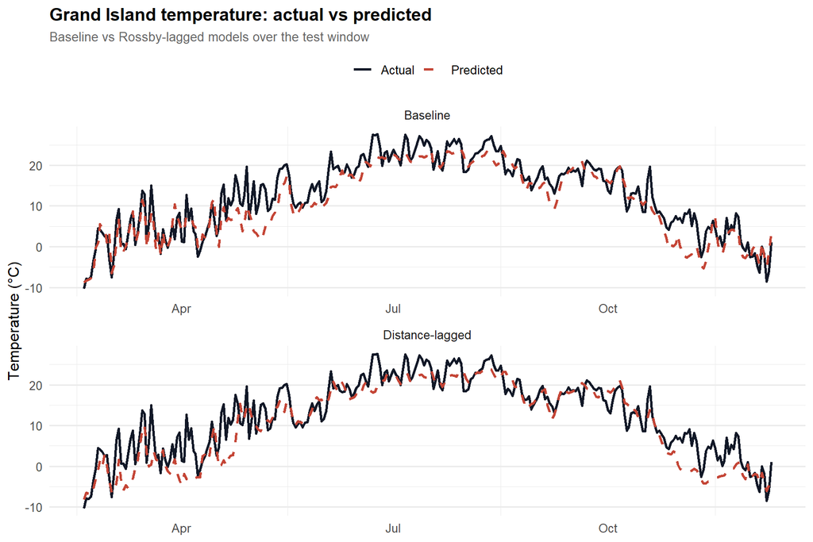

Figure 3: Actual vs predicted (baseline vs distance-lagged)

```r
dates_base <- test0$date[(LOOKBACK + 1):nrow(test0)]
dates_lag  <- test_lag$date[(LOOKBACK + 1):nrow(test_lag)]

pred_df <- bind_rows(
  tibble(date = dates_base, actual = seq_te_base$y, pred = res_base$preds, Model = "Baseline"),
  tibble(date = dates_lag,  actual = seq_te_lag$y,  pred = res_lag$preds,  Model = "Distance-lagged")
)

ggplot(pred_df, aes(x = date)) +
  geom_line(aes(y = actual, color = "Actual"), linewidth = 0.9) +
  geom_line(aes(y = pred, color = "Predicted"), linewidth = 0.9, linetype = "dashed") +
  facet_wrap(~ Model, ncol = 1, scales = "free_x") +
  scale_color_manual(
    values = c(
      "Actual"    = "#111827",
      "Predicted" = "#c44536"
    )
  ) +
  labs(
    title = "Grand Island temperature: actual vs predicted",
    subtitle = "Baseline vs Rossby-lagged models over the test window",
    x = NULL,
    y = "Temperature (°C)",
    color = NULL
  ) +
  theme_minimal(base_size = 12) +
  theme(
    plot.title = element_text(face = "bold", size = 14),
    plot.subtitle = element_text(size = 10, color = "gray40"),
    legend.position = "top",
    panel.grid.major.x = element_blank()
  )
```

# 4) Main model performance

Using the best-performing time representation, the final model achieves stable test-set performance with errors in line with operational short-range forecasts. The model captures both day-to-day variability and broader seasonal trends, with residuals centered near zero. These results indicate that combining upstream spatial information with sequence modeling provides meaningful predictive signal without overfitting.

```r
# Use cyclical encoding on the original wide data
tr <- train0 %>% mutate(
  doy = yday(date),
  doy_sin = sin(2*pi*doy/365.25),
  doy_cos = cos(2*pi*doy/365.25)
)
te <- test0 %>% mutate(
  doy = yday(date),
  doy_sin = sin(2*pi*doy/365.25),
  doy_cos = cos(2*pi*doy/365.25)
)

xcols <- setdiff(names(tr), c("date", target_col))
fit <- zfit(tr, xcols)
trn <- zapply(tr, xcols, fit)
ten <- zapply(te, xcols, fit)

seq_tr <- make_sequences(trn, xcols, target_col, LOOKBACK)
seq_te <- make_sequences(ten, xcols, target_col, LOOKBACK)

main_res <- train_one(seq_tr, seq_te, epochs = EPOCHS, batch = BATCH)

main_metrics <- tibble(
  RMSE = rmse(main_res$preds, seq_te$y),
  MAE  = mae(main_res$preds,  seq_te$y)
)
main_metrics
```

```
# A tibble: 1 × 2
   RMSE   MAE
  <dbl> <dbl>
1  2.66  2.06
```

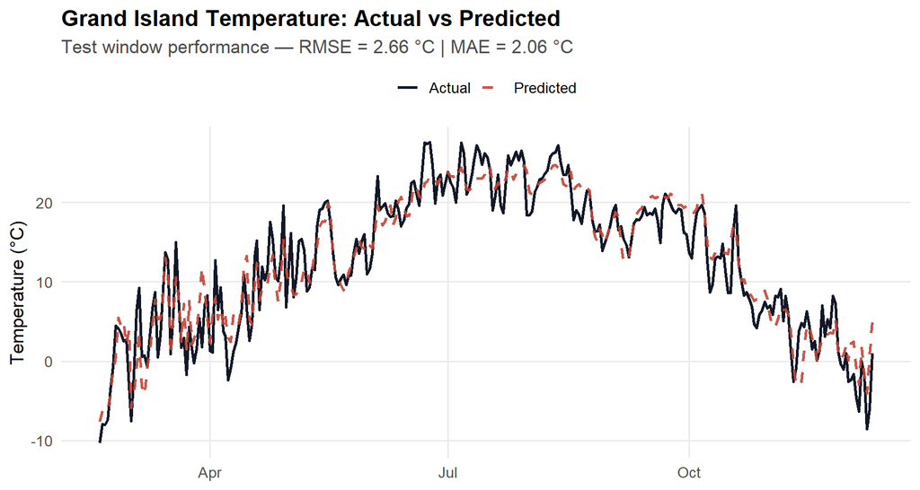

Figure 4: Main model: actual vs predicted (test window)

```r
dates_main <- te$date[(LOOKBACK + 1):nrow(te)]
plot_df <- tibble(date = dates_main, actual = seq_te$y, pred = main_res$preds)

ggplot(plot_df, aes(x = date)) +
  geom_line(aes(y = actual, color = "Actual"), linewidth = 1.0) +
  geom_line(aes(y = pred,   color = "Predicted"), linewidth = 0.9, linetype = "dashed", alpha = 0.9) +
  scale_color_manual(
    values = c("Actual" = "#111827", "Predicted" = "#c44536")
  ) +
  labs(
    title = "Grand Island Temperature: Actual vs Predicted",
    subtitle = paste0(
      "Test window performance — RMSE = ",
      sprintf("%.2f", main_metrics$RMSE),
      " °C | MAE = ",
      sprintf("%.2f", main_metrics$MAE),
      " °C"
    ),
    x = NULL,
    y = "Temperature (°C)",
    color = NULL
  ) +
  theme_minimal(base_size = 13) +
  theme(
    plot.title = element_text(face = "bold"),
    plot.subtitle = element_text(color = "grey30"),
    legend.position = "top",
    panel.grid.minor = element_blank()
  )
```

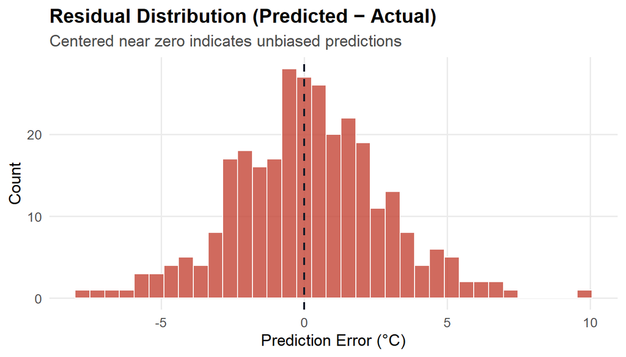

Figure 5: Residuals on the test window (Predicted − Actual)

```r
resid <- plot_df$pred - plot_df$actual

ggplot(tibble(resid = resid), aes(x = resid)) +
  geom_histogram(
    bins = 35,
    fill = "#c44536",
    alpha = 0.8,
    color = "white"
  ) +
  geom_vline(
    xintercept = 0,
    linetype = "dashed",
    linewidth = 0.8,
    color = "#111827"
  ) +
  labs(
    title = "Residual Distribution (Predicted − Actual)",
    subtitle = "Centered near zero indicates unbiased predictions",
    x = "Prediction Error (°C)",
    y = "Count"
  ) +
  theme_minimal(base_size = 13) +
  theme(
    plot.title = element_text(face = "bold"),
    plot.subtitle = element_text(color = "grey30"),
    panel.grid.minor = element_blank()
  )
```

## 5) Mechanistic interpretability

**Mechanistic interpretabilityMethods that probe how a neural network uses its inputs internally, helping explain why a model makes particular predictions rather than just how accurate it is.** asks a deeper question than accuracy alone: what information is the model actually using? Neural networks like LSTMs are often treated as black boxes because their internal logic is difficult to inspect directly. Mechanistic interpretability techniques aim to open this box by observing how model behavior changes when specific inputs are deliberately disrupted.

Here, we use permutation importance as a practical interpretability tool. Each input feature is randomly shuffled in turn, and the resulting increase in **RMSERoot Mean Squared Error (penalizes large errors more).** is measured. If shuffling a feature causes a large drop in performance, the model is strongly relying on that information. For compatibility with a sequence model, importance is computed using a tabular snapshot taken from the final timestep of each input sequence.

The results show that the model relies most heavily on upstream temperature variables, not on calendar features alone. While cyclical time encoding provides helpful seasonal context, the strongest importance scores come from physically meaningful inputs such as temperatures from Chicago, Minneapolis, and Thunder Bay. This indicates that the LSTM is learning real spatio-temporal structure rather than simply memorizing seasonal patterns.

```r
if (!requireNamespace("iml", quietly = TRUE)) {
  stop("Please install iml: install.packages('iml')")
}
library(iml)


X_tab <- as.data.frame(seq_tr$X[, LOOKBACK, ])
colnames(X_tab) <- xcols
Y_tab <- seq_tr$y

predict_lstm <- function(m, newdata) {
  arr <- array(as.matrix(newdata), dim = c(nrow(newdata), LOOKBACK, ncol(newdata)))
  storage.mode(arr) <- "double"
  as.numeric(m$predict(arr, verbose = 0)[,1])
}

pred_obj <- Predictor$new(
  model = main_res$model,
  data  = X_tab,
  y     = Y_tab,
  predict.function = predict_lstm
)

imp <- FeatureImp$new(pred_obj, loss = "rmse", n.repetitions = 5)
imp_df <- imp$results %>% arrange(desc(importance))
imp_df
```

```
                  feature importance.05 importance importance.95
1         tempmax_Chicago     1.0583400  1.0591106     1.0599125
2     tempmin_Minneapolis     1.0456032  1.0471587     1.0492720
3         tempmin_Chicago     1.0377812  1.0394850     1.0401737
4        temp_Minneapolis     1.0347979  1.0376080     1.0378985
5            temp_Chicago     1.0366027  1.0370611     1.0374343
6     tempmax_Minneapolis     1.0350107  1.0366284     1.0372746
7         temp_ThunderBay     1.0337567  1.0359128     1.0363411
8      tempmin_ThunderBay     1.0271849  1.0307992     1.0316093
9     tempmin_GrandIsland     1.0191712  1.0196217     1.0206215
10     tempmax_ThunderBay     1.0163175  1.0181078     1.0187231
11     precip_Minneapolis     1.0093016  1.0106792     1.0116313
12      precip_ThunderBay     1.0060889  1.0072897     1.0076687
13    tempmax_GrandIsland     1.0064596  1.0069397     1.0079376
14                    doy     1.0028351  1.0047294     1.0066058
```

[output cut: 47 more lines]

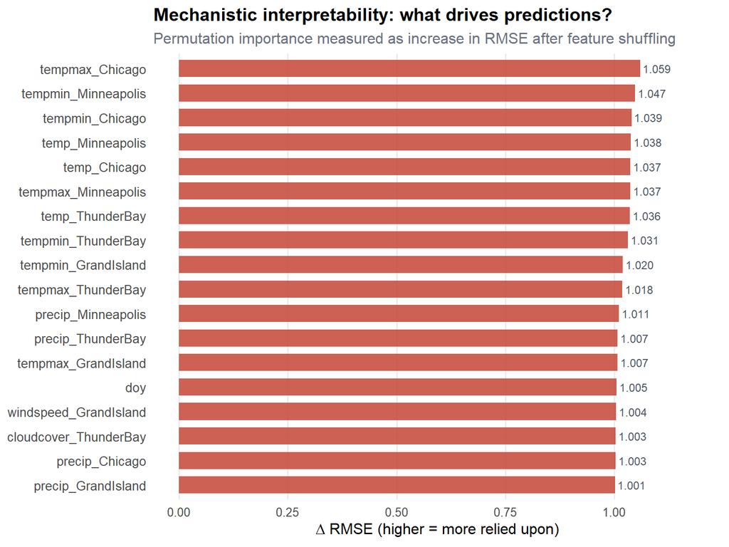

```r
top_n <- 18
plot_imp <- imp_df %>% slice_head(n = top_n)

ggplot(plot_imp,
       aes(x = reorder(feature, importance), y = importance)) +
  geom_col(
    fill = "#c44536",
    alpha = 0.85,
    width = 0.7
  ) +
  coord_flip() +
  geom_text(
    aes(label = sprintf("%.3f", importance)),
    hjust = -0.1,
    size = 3.2,
    color = "#4b5563"
  ) +
  labs(
    title = "Mechanistic interpretability: what drives predictions?",
    subtitle = "Permutation importance measured as increase in RMSE after feature shuffling",
    x = NULL,
    y = expression(Delta * " RMSE (higher = more relied upon)")
  ) +
  theme_minimal(base_size = 12) +
  theme(
    plot.title = element_text(face = "bold"),
    plot.subtitle = element_text(color = "#6b7280"),
    panel.grid.major.y = element_blank(),
    panel.grid.minor = element_blank(),
    axis.text.y = element_text(size = 10)
  ) +
  expand_limits(y = max(plot_imp$importance) * 1.12)
```

# 6) Glossary

- **Cyclical DOY encodingDay-of-year; we encode it as sin/cos for smooth yearly seasonality.**
- **LSTMLong Short-Term Memory neural network (sequence model).**
- **RMSERoot Mean Squared Error (penalizes large errors more).**
- **MAEMean Absolute Error (average absolute error).**
- **Permutation importancePermutation importance: shuffle one input and measure error increase.**
- **Rossby wavesLarge-scale atmospheric waves in the mid-latitudes that shape jet stream patterns and guide the eastward movement of weather systems.**
- **DOY cyclical encodingDay-of-year; we encode it as sin/cos for smooth yearly seasonality.**